[interactive chart not shown]

# Interpretable & Uncertainty-Aware Bayesian Modeling

sentiment classification with text data · chaotic time series

**BAMIC** · Bayesian attention-based  
multiple-instance classification **BPAR** · Bayesian Bernstein  
polynomial autoregression

**Li Yuan (Leon)**  
Department of Statistics and Data Science · Southern Methodist University  
with coauthors Raanju R. Sundararajan and Jing Cao

two projects · two explicit models

## Different data, separate architectures — the same inferential goal.

### BAMIC

sentiment classification with text data

[figure not shown]

**Readable unit:** each word's additive contribution, with posterior uncertainty attached.

### BPAR

chaotic time-series forecasting

[figure not shown]

**Readable unit:** each lag's nonlinear response curve, with a posterior forecast distribution.

one recipe

## Structure → priors → posterior — for everything you care about.

01

### Small, structured, readable

**BAMIC <1%** of transformer parameters · **AR-BPAR ≤300** coefficients in the 19-series study

→

02

### Priors on the coefficients that matter

shrinkage where complexity hides; weakly-informative where it doesn't

→

03

### Scalable Bayesian inference

variational posteriors — or exact conjugate updates when structure allows

BAMIC

which **words** carry sentiment, with what confidence

BPAR

which **lags** drive a chaotic time series, with honest forecast bands

BAMIC · problem

## 141,904 reviews. One label each. Which words carry the sentiment?

wine review · label: positive (rating ≥ 90)words: latent

Aromas of ripe plum and mocha; silky tannins and a long, polished finish, though a bitter edge and drying oak blur the final impression.

AMIC (attention-based multiple-instance classification) finds them — as **point estimates**. Solid words it asserts; dotted words it asserts just as loudly.

BAMIC · model

## BAMIC — put the priors where the meaning lives.

**Layer 1** — selection gate δ<sub>ij</sub> : is word j sentiment-bearing? **Layer 2** — score Z<sub>ij</sub> : how positive / negative? **Priors on b, β** → posteriors propagate through everything

BAMIC · live posterior

## Explanations, with error bars.

draw 000

posterior draw of (b, β) → δ·Z per wordbar under word = 95% credible interval

P(POSITIVE)

0.87 [0.79, 0.93]

2.2×

predictive entropy on **wrong** vs correct predictions (0.539 / 0.246)

2.3×

95% interval width, wrong vs correct (0.0275 / 0.0122)

S=100

posterior draws per document — uncertainty that flags its own mistakes

live animation is schematic; mechanism & statistics from the manuscript (wine-review test set)

BAMIC · results

## Within 1.3 points of BERT — with less than 1% of its parameters.

| model | test accuracy | trainable parameters | word-level explanation + posterior uncertainty |
| --- | --- | --- | --- |
| BERT-base transformer | 0.8877 | 109.5M | not built into evaluated baseline |
| RoBERTa-base transformer | 0.8854 | 124.6M | not built into evaluated baseline |
| BiLSTM frozen GloVe | 0.8769 | 0.441M | not built into evaluated baseline |
| BAMIC frozen GloVe | 0.8749 | 0.934M | **exact additive contributions + credible intervals** |
| CNN frozen GloVe | 0.8622 | 0.361M | not built into evaluated baseline |

**117×**

BERT has 117 times as many trainable parameters as BAMIC.

**1.28 pts**

Wine accuracy gap from BAMIC to the strongest evaluated model.

**one model**

Prediction, additive word evidence, and posterior uncertainty together.

Source: *BAMIC: Interpretable Sentiment Classification with Bayesian Uncertainty and Word-Level Contributions* — manuscript under review · Wine test set, n = 10,000, threshold 0.5.

BPAR · chaotic time series

## What makes a time series chaotic?

[interactive chart not shown]

initial gap δ₀

time t = 80

**A chaotic time series** follows deterministic nonlinear rules, yet nearby initial histories can separate rapidly. Sensitive dependence limits long-horizon predictability even without external noise.

ẋ(*t*) = 0.2*x*(*t*−17) / [1 + *x*(*t*−17)<sup>10</sup>] − 0.1*x*(*t*)

x(t) = current state; **17** = delay; **0.2** = delayed feedback; **0.1** = decay.

δ₀ = ‖φ̃−φ‖<sub>∞</sub>; Δ<sub>t</sub> = x̃(*t*)−x(*t*)

φ, φ̃ = initial histories; δ₀ = their initial gap; Δₜ = separation at time *t*.

A<sub>t</sub> = |Δ<sub>t</sub>|/δ₀; A<sub>t</sub><sup>peak</sup> = max<sub>0≤s≤t</sub> |Δ<sub>s</sub>|/δ₀

Aₜ = separation now in initial-gap units; Aₜ<sup>peak</sup> = largest ratio observed through *t*.

current amplification 1.0× · peak 1.0×

Current = separation now; peak = largest normalized separation so far. Not a probability or a Lyapunov-exponent estimate.

BPAR · approximation theory

## Bernstein approximation theory — fixed basis, flexible lag effects.

[interactive chart not shown]

degree m = 3

**4** basis units RMS **—** max gap **—**

*B<sub>k,m</sub>*(*z*) = C(*m*,*k*)*z*<sup>*k*</sup>(1−*z*)<sup>*m−k*</sup>

z ∈ [0,1] is the scaled lag; m is the degree; k indexes the basis; **C(m,k)** is the binomial coefficient.

(*ℬ<sub>m</sub>f*)(*z*) = Σ<sub>*k*=0</sub><sup>*m*</sup> *f*(*k/m*) *B<sub>k,m</sub>*(*z*)

ℬₘf blends the sampled values f(k/m) using nonnegative basis weights that sum to one.

‖ℬ<sub>m</sub>f − f‖<sub>∞</sub> → 0 for *f* ∈ C[0,1]

As m increases, the **largest approximation error anywhere on [0,1]** tends to zero.

**BPAR replaces sampled values with learned coefficients:**

*g<sub>j</sub>*(*z*) ≈ Σ<sub>k=0</sub><sup>m</sup> *w<sub>j,k</sub>**B<sub>k,m</sub>*(*z*)

gⱼ(z) = nonlinear response of lag *j*; wⱼ,ₖ = learned coefficient for basis *k*.

model structures · interactive flow

## Two compact models — every arrow has a statistical meaning.

stage 1 / 5 · inputs

### BAMIC

Bayesian attention-based multiple-instance classification

0.934M trainable · 1,204 variational values

[figure not shown]

### BPAR

Bayesian Bernstein polynomial autoregression

8–300 parameters · one structured layer

[figure not shown]

BPAR · inference

## Shrinkage priors adapt the model's effective complexity.

prior sd of w<sub>j,k</sub> — fades with lag j and degree k

#### Route 1 · variational

Gaussian family, reparameterized gradients — scales to any BPAR

#### Route 2 · exact conjugate

AR-BPAR is linear-in-coefficients → Normal–Inverse-Gamma posterior in **closed form**. No MCMC, no approximation.

→ every forecast ships with a posterior predictive **band**, not a dot.

BPAR · forecast

## Forecasting chaos, with uncertainty on every horizon.

[interactive chart not shown]

forecast horizon h = 150 h 150 · width —

held-out truth (schematic trace) AR-BPAR posterior mean (schematic) 95% predictive band (schematic) neural point forecasts (schematic)

11×

lower test RMSE than LSTM on Mackey–Glass (0.0016 vs 0.0181)

2.1×

better than the best classical baseline, SARIMA (0.0034)

95%

posterior predictive bands available directly from the posterior

BPAR · results

## Across 19 series, AR-BPAR ranks first — with at most 300 parameters.

mean held-out test-RMSE rank · 18 methods · lower is better

AR-BPAR4.89

RidgeAR5.58

Transformer5.84

DeepAR6.11

BPAR6.16

N-HiTS7.00

representative size comparison

| dataset | AR-BPAR | evaluated NN/DL range | RMSE vs best NN/DL |
| --- | --- | --- | --- |
| Beijing PM<sub>2.5</sub> | 49 | 961–819,751 | 0.432 vs 0.421 |
| Ontario electricity | 65 | 257–819,751 | 0.760 vs 0.727 |

8–300

parameters across all selected AR-BPAR configurations (median 69)

0.92

median empirical coverage for nominal 90% posterior predictive intervals

Source: *BPAR: Interpretable Bayesian Bernstein Autoregression for Nonlinear Time Series Forecasting* — manuscript under review. RMSE values use each dataset's manuscript preprocessing scale.

BPAR · real-series forecasts

## Competitive posterior forecasts — Ontario and Beijing.

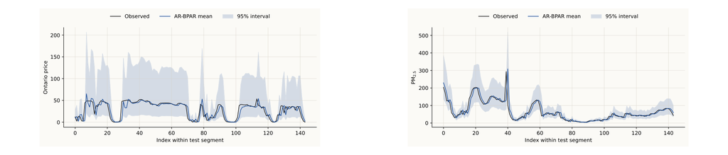

#### Ontario electricity · 65 parameters

AR-BPAR RMSE 0.760 vs best evaluated NN/DL 0.727 · empirical coverage: 0.84 at 90%, 0.89 at 95%.

#### Beijing PM<sub>2.5</sub> · 49 parameters

AR-BPAR RMSE 0.432 vs best evaluated NN/DL 0.421 · empirical coverage: 0.83 at 90%, 0.90 at 95%.

Held-out test forecasts from the BPAR manuscript under review · values use the submitted manuscript's transformed/scaled evaluation protocol.

synthesis

## The design pattern transfers; the mathematics changes.

|  | BAMIC · text | BPAR · chaotic series |
| --- | --- | --- |
| readable structure | selection gate δ · word score Z | Bernstein block per lag |
| priors where meaning lives | Gaussians on b, β (+ soft sparsity penalties) | lag- & degree-adaptive shrinkage on w<sub>j,k</sub> |
| inference | variational · Bayes-by-Backprop | variational · exact conjugate |
| interpretable unit | a word's contribution, with an interval | a lag's response curve, with an interval |
| where they differ | local latent word roles · approximate posterior | global nonlinear lag structure · an exact route is available |
| uncertainty that works | 2.2× entropy on its own errors | predictive bands on chaotic horizons |

what's next

## The program: make trustworthy the default.

now · text

#### Abstention that pays

entropy already flags BAMIC's own errors → selective prediction at practical coverage; phrase-level structure for negation & contrast

now · chaotic series

#### Beyond one series

multivariate & spatio-temporal BPAR; regime-switching lag blocks with the same conjugate backbone

bridge

#### Glass heads on deep bodies

Bayesian interpretable layers on transformer representations — keep the readable decomposition, borrow the context

thesis

#### Trust as a modeling question

where can structured Bayesian models close the performance gap while making *why* and *how sure* part of the model?

[interactive chart not shown]

thank you

## Models you can read. Uncertainty you can act on.

I

Structure makes the model readable — words and lags remain explicit.

II

Priors make the structure honest — complexity only where data earn it.

III

Posteriors make honesty measurable — bands, entropy, abstention.

Li Yuan (Leon) · yuanli@smu.edu  
questions welcome — backup slides: press B

backup · A1

## BAMIC — archived full-corpus ablation

| configuration | Accuracy | F1 | AUC | Brier | NLL | ECE |
| --- | --- | --- | --- | --- | --- | --- |
| Keep full text (uninterpretable baseline) | 0.8653 | 0.8187 | 0.9467 | 0.0941 | 0.2960 | 0.0574 |
| Remove boilerplate (hard preprocessing) | 0.8133 | 0.7614 | 0.9110 | 0.1291 | 0.3948 | 0.0977 |
| No penalties (λ<sub>B</sub>=λ<sub>S</sub>=0) — gate collapse | 0.8458 | 0.8047 | 0.9471 | 0.1088 | 0.3388 | 0.1017 |
| λ<sub>B</sub>=0.05, λ<sub>S</sub>=0.005 | 0.8475 | 0.8064 | 0.9468 | 0.1068 | 0.3350 | 0.1017 |
| Boilerplate only, λ<sub>B</sub>=0.10 | 0.8632 | 0.8160 | 0.9454 | 0.0964 | 0.3022 | 0.0631 |
| ★ Preferred: λ<sub>B</sub>=0.10, λ<sub>S</sub>=0.01 | 0.8620 | 0.8168 | 0.9456 | 0.0982 | 0.3088 | 0.0706 |
| λ<sub>B</sub>=0.10, λ<sub>S</sub>=0.02 | 0.8575 | 0.8127 | 0.9454 | 0.0997 | 0.3136 | 0.0764 |

Archived earlier configuration: 141,904 wine reviews · 127,713 / 7,095 / 7,096 split. The main result slide uses the submitted gate-fixed benchmark (n=10,000 test); do not combine values across these protocols.

backup · A2

## BPAR — earlier six-dataset study, raw-unit RMSE

| chaotic | ARIMA | SARIMA | MLP | LSTM | BPAR† |
| --- | --- | --- | --- | --- | --- |
| Ricker | 2.14 | 2.23 | 0.40 | — | 0.30 |
| Logistic map | 0.2438 | 0.2478 | 0.0141 | 0.0174 | 0.0115 |
| Gauss map | 0.0840 | 0.0486 | 0.0130 | — | 0.0083 |
| Mackey–Glass | 0.0330 | 0.0034 | 0.0179 | 0.0181 | 0.0016 |

| real | ARIMA | SARIMA | MLP | LSTM | AR-BPAR |
| --- | --- | --- | --- | --- | --- |
| Ontario demand | 9.58 | 9.77 | 10.81 | 9.47 | 9.57 / 9.78ᵇ |
| Beijing PM<sub>2.5</sub> | 37.00 | 37.01 | 36.41 | 36.19 | 36.13ᵇ |

Earlier protocol shown in original units. The main BPAR result and forecast slides use the expanded 19-series submitted-manuscript protocol and transformed/scaled RMSE; values from the two protocols should not be combined.

backup · A3

## Inference details

variational route (both models)

ℒ = 𝔼<sub>*q*</sub>[log *p*(*y* | *θ*)] − KL(*q*(*θ*) ∥ *p*(*θ*))

ℒ = variational objective; q(θ) = approximate posterior; p(θ) = prior; **KL** penalizes departure from the prior.

Factorized Gaussian *q* · reparameterization θ = µ + softplus(ρ)·ε · closed-form KL · BAMIC: one Monte Carlo draw per batch.

conjugate route (AR-BPAR)

*θ* | *σ*² ∼ 𝒩(*m*₀, *σ*²*V*₀)  
*σ*² ∼ InvGamma(*a*₀, *b*₀)

θ = regression coefficients; σ² = noise variance; m₀,V₀,a₀,b₀ = prior hyperparameters.

The linear-in-coefficients likelihood gives a closed-form Normal–Inverse-Gamma posterior; prior variances decay with lag *j* and basis index *k*.

backup · manuscripts under review

## Research presented in this talk

manuscript under review · BAMIC

**Yuan, L., Sundararajan, R. R., & Cao, J.** (manuscript under review).

### BAMIC: Interpretable Sentiment Classification with Bayesian Uncertainty and Word-Level Contributions

Bayesian attention-based multiple-instance classification for intrinsically interpretable text prediction.

manuscript under review · BPAR

**Yuan, L., & Sundararajan, R. R.** (manuscript under review).

### BPAR: Interpretable Bayesian Bernstein Autoregression for Nonlinear Time Series Forecasting

Bayesian Bernstein polynomial autoregression for nonlinear and chaotic time-series forecasting.

15:00 1 / 17

→ advance · M motion · N notes · O index · T timer · ? help

speaker notes

### Presenting this deck

→ space advance build / slide · ← back

S draw a posterior sample (demo slide) · R replay this slide's animation

P play / pause the active time-series reveal · C restart the chaos comparison

M toggle full animation on / off. The deck defaults to motion on in Chrome, even when the operating system requests reduced motion.

T start / pause the 15:00 presenter timer (click the clock too) · shift-T resets

N speaker notes · O slide index · B backup slides · F fullscreen

1–5 jump to section: Opening · Sentiment · Time Series · Synthesis · Backup

Slides deep-link (#7) — refresh returns to the same slide. Presenting: fullscreen (F), timer (T), and rehearse with notes (N) open.

Timer pacing: Opening ends ≈ 1:55 · BAMIC ≈ 5:35 · BPAR ≈ 11:45 · final words by 14:20, leaving a 40-second buffer. The progress bar marks section transitions.

Works offline — fonts degrade gracefully to Georgia / system faces if there's no network in the room.